# Working example for “Model-agnostic unsupervised detection of bots in a Likert-type questionnaire”

Michael John Ilagan and Carl F. Falk

2023 April 9

# Introduction

This document is a working example of our proposed approach to bot detection, called L1P1 in the companion article, [Model-agnostic unsupervised detection of bots in a Likert-type questionnaire](https://psyarxiv.com/nu26z/). In this document, We do as follows:

1. load a dataset;
2. apply the algorithm; and
3. inspect the results.

We assume that the working directory has the required R script files. From these script files, we load into our workspace the functions implementing our algorithm. No packages required.

```r
# helper functions
source("helper-general.R")
source("helper-unsuperv.R")
```

# Step 1: Load the dataset

We begin by loading the test set raw Likert-type data. For this demonstration, we will follow the procedure in the paper, which is to sample humans from a real dataset, simulate bots, then put them together as one sample. Of course, if you have your own dataset, you should load that instead.

```r
# load test set
n0 = 5 # set number of humans
n1 = 95 # set number of bots
url = "https://vincentarelbundock.github.io/Rdatasets/csv/psych/bfi.csv"
pointscale = 6 # number of likert categories in the data
set.seed(409)
likert = with(new.env(),{
    # get humans
    humandata = read.csv(url)[,2:26]
    sampledrows = sample(1:nrow(humandata),size=n0,replace=TRUE)
    zte0 = humandata[sampledrows,]
    # make bots
    zte1 = rbot(n1,pointscale=pointscale,numitems=ncol(humandata),prob=NULL)
    # mix humans and bots
    rbind(as.matrix(zte0),zte1)
})
```

Note that because this is a toy example, we know the true classes, so we can easily evaluate the algorithm’s performance. In a real setting, such information may be unavailable.

```r
# true class labels
yte = c(rep("human",n0),rep("bot",n1))
table(yte)
```

```
## yte
##   bot human
##    95     5
```

# Step 2: Execute algorithm

The function `detectbotseasy` does L1P1. Arguments are:

- `likert`, the raw Likert-type data matrix (denoted $Z$ in the paper);
- `numbotseach`, how many synthetic bots to generate per test set respondent (denoted $B$ in the paper);
- `pointscale`, the number of Likert-type response categories; and
- `threshold`, the p-value cutoff for sparing or flagging the respondent.

- `pval`, a vector of p-values;
- `nri_obs`, a matrix of locations for the test set respondents (denoted $X$ in the paper);
- `nri_synth`, a matrix of NRI locations for the synthetic bots (denoted $X^{\mathbb{tr}}$ in the paper); and
- `familyid`, a vector which tracks to which respondent each synthetic bot is associated with.

```r
# execute algorithm
set.seed(42)
detection = detectbotseasy(likert,numbotseach=200,pointscale=pointscale,
threshold=0.05)
str(detection)
```

```
## List of 5
##  $ pval     : num [1:100] 0.00995 0.50746 0.02488 0.04478 0.06965 ...
##  $ nri_obs  : num [1:100, 1:2] 4.84 5.73 3.99 4.23 5.97 ...
##   ..- attr(*, "dimnames")=List of 2
##   .. ..$ : NULL
##   .. ..$ : chr [1:2] "mahal" "ptc"
##  $ nri_synth: num [1:20100, 1:2] 4.84 5.99 6.28 5.28 4.96 ...
##   ..- attr(*, "dimnames")=List of 2
##   .. ..$ : NULL
##   .. ..$ : chr [1:2] "mahal" "ptc"
##  $ familyid : int [1:20100] 1 1 1 1 1 1 1 1 1 1 ...
##  $ yhat     : chr [1:100] "spare" "kill" "spare" "spare" ...
```

# Step 3: Inspect the results

If we know the true classes, we can evaluate some performance metrics, such as accuracy and sensitivity. We say “kill” when predicted class is bot and “spare” when predicted class is human.

```r
# performance metrics
perfmet(y=yte,yhat=detection$yhat)
```

```
## $confusion
##        yhat
## y       kill spare
##   bot     92     3
##   human    2     3
##
## $outcomemeasures
##       acc      spec      sens       ppv       npv  killrate
## 0.9500000 0.6000000 0.9684211 0.9787234 0.5000000 0.9400000
```

If we know the true classes, it would also make sense to inspect p-value boxplots by class. Bots tend to have uniformly distributed p-values, while humans tend to have lower p-values.

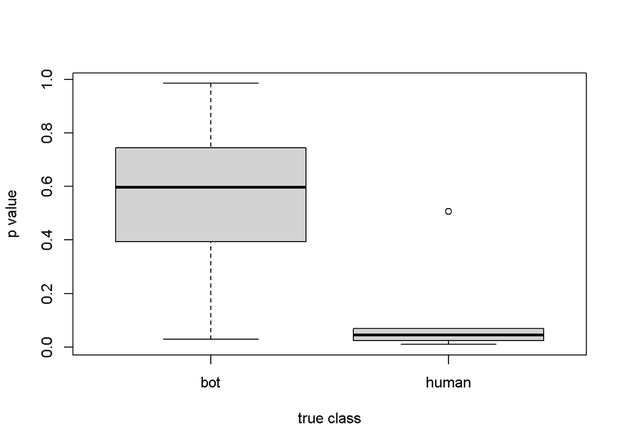

```r
# p value boxplots by class
boxplot(detection$pval~yte,xlab="true class",ylab="p value")
```

We can also plot the feature space, using the function `nriplot`. Arguments are:

- `xte`, a matrix of feature locations of the test set respondents;
- `xtr`, a matrix of feature locations of the training set respondents;
- `yhat`, a vector of predicted classes (must be “spare” vs. “kill”);
- `yte`, a vector of class labels for the test set respondents (must be “human” vs. “bot”);
- `ytr`, a vector of class labels for the training set respondents (must be “human” vs. “bot”);
- `plottrain`, a boolean whether to plot the training set respondents;
- `getpc`, a boolean whether to use the principal components of the NRIs; and
- `trplotlim`, a boolean whether the limits of the plot accomodate all training set locations.

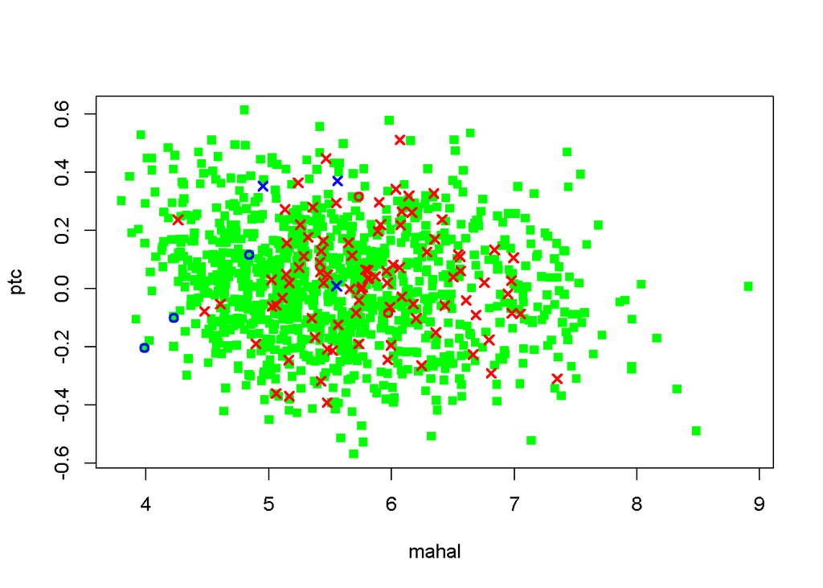

```r
# view feature space
invisible(nriplot(xte=detection$nri_obs,
xtr=detection$nri_synth[detection$familyid%in%(1:5),],yhat=detection$yhat,
yte=yte,ytr=NULL,plottrain=TRUE,getpc=FALSE,trplotlim=TRUE))
```

# Using your own data

You are now ready to detect bots in your own dataset. It takes only a few lines of code, assuming your Likert-type data matrix is saved as `likert`, and the number of Likert-type categories is saved as `pointscale`. Remember to set the seed for reproducibility. The next code block is not run in this document—you will run it yourself in your own R session.

```r
set.seed(42) # reproducibility
detection = detectbotseasy(likert,numbotseach=200,
pointscale=pointscale) # execute algorithm
detection$yhat # predictions
```